# Un modelo de eficiencia del combustible

## Objetivo

El diccionario de variables se encuentrá en el siguiente link https://www.fueleconomy.gov/feg/ws/index.shtml#fuelType1.

El objetivo principal de este post es lograr crear un modelo que determine la eficiencia del combustible dada la información disponible y segundo poder describir de manera corta y eficiente la data. Para ello usaré dos paquetes en R que considero primordiales, para el trabajo de analítica [moderndive](https://moderndive.com/2-viz.html#linegraphs) y para el desarrollo de los modelos [statisticalModeling](https://www.rdocumentation.org/packages/statisticalModeling/versions/0.3.0).

Dado que mi conocimiento sobre combustibles es poco, usaré de manera académica algunos conceptos sobre *FUEL* y algunos conceptos económicos.

Como Científico de Datos, lo que más llama mi atención es tener la libertad de jugar con la data de manera que pueda diseñar conocimiento sobre la misma, por lo cual intentaré llegar a un punto de research profundo, más como estadístico quiero darle importancia a los p-values que descubra en el camino.

## Características de la base de datos

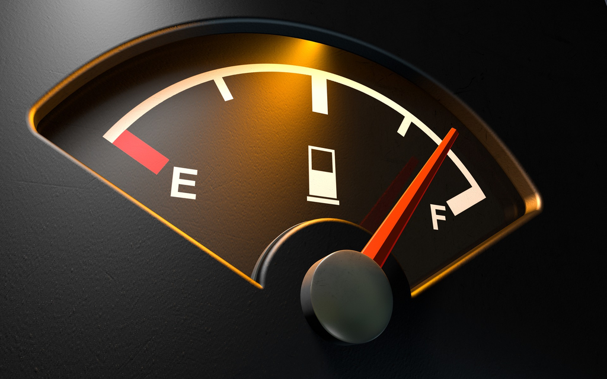

Después de leer un poco al respecto de la base de datos , encuentro que existen dos tipos de vehículos, Electricos y tradiciionales.

Con respecto a ello destaco las siguientes variables que creo que pueden ayudar al desarrollo de unas ideas generales:

- MPG: Miles Per Galon
- Fuel Type 1 : Conventional Fuel
- Fuel Type 2 : Alternative Fuel (Electric , CNC, LPG)
- displ : Engine displacement in liters
- City08 : MPG for City for fuelType1
- Highway08: highway MPG for fuelType1

El comportamiento de city08 y de highway08 es el siguiente

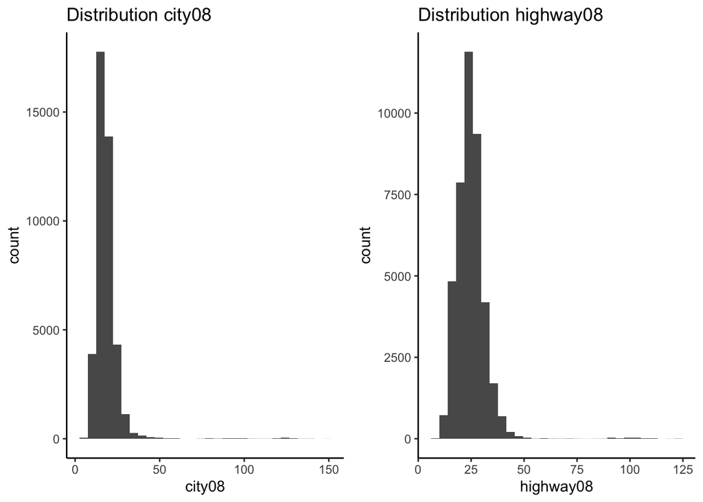

Al estudiar el comportamiento de manera log para determinar de manera apropiada la distribución de los datos se encuentra lo siguiente

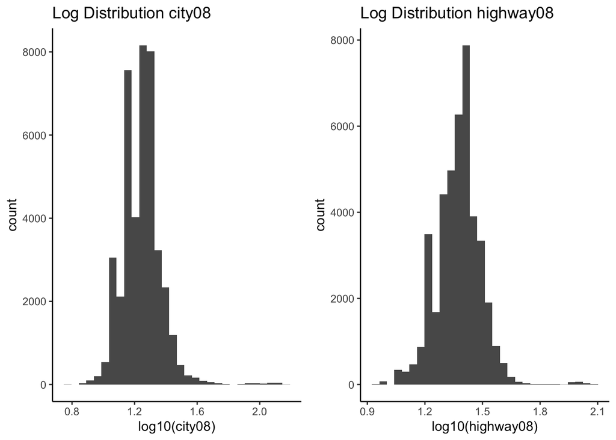

Al ver este tipo de distribución se puede trabajar una relación entre ellas, para obtener un primer acercamiento a algun tipo de conocimiento

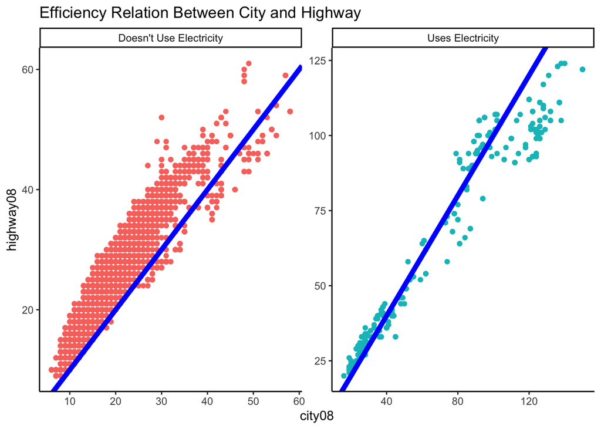

Las correlaciones son interesantes en este punto pues la relación entre los vehículos que son Electricos y los que no muestran que los primeros tienen un nivel de eficiencia más alto, sospecho que esto tiene que ver con una correlación escalonada, y por ello desarrollaré los siguientes pasos

```
##
## Correlation method: 'pearson'
## Missing treated using: 'pairwise.complete.obs'
```

```
## # A tibble: 4 x 5
##   rowname   city08 highway08  displ cylinders
##   <chr>      <dbl>     <dbl>  <dbl>     <dbl>
## 1 city08    NA         0.970 -0.550    -0.512
## 2 highway08  0.970    NA     -0.546    -0.481
## 3 displ     -0.550    -0.546 NA         0.961
## 4 cylinders -0.512    -0.481  0.961    NA
```

Notesé el efecto de los cilindros y displ sobre el efecto de city08, por lo cual si se evalua a manera de disribución de rendimiento el resultado es el siguiente

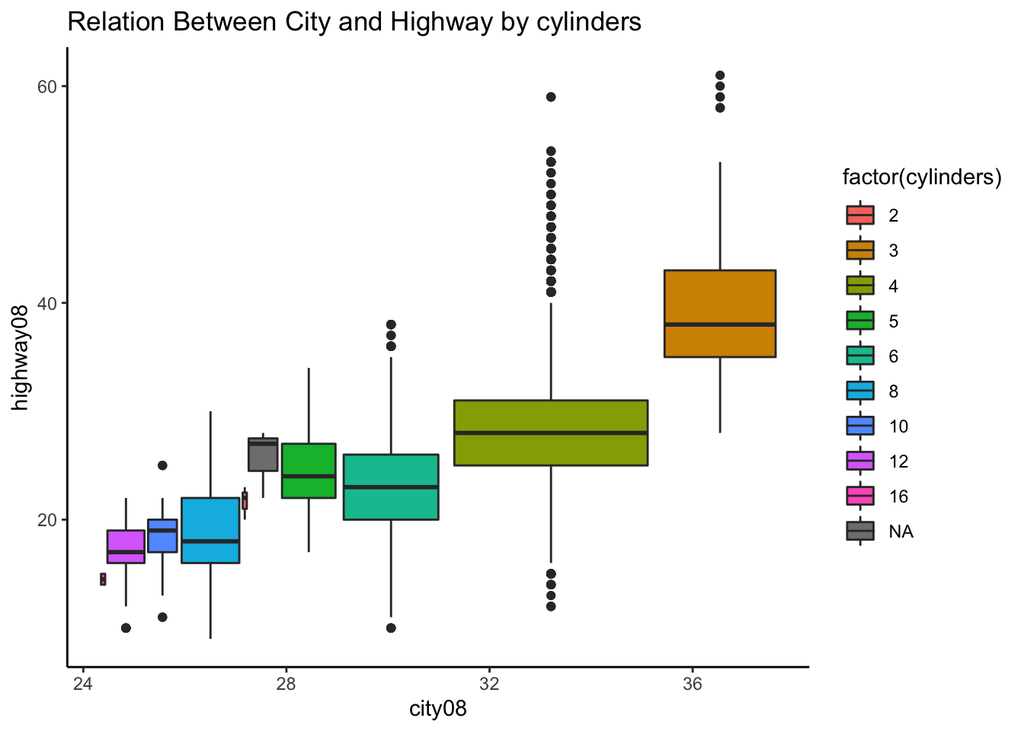

Lo anterior muestra algo evidente y es que a menor número de cilindros es mayor el rendimiento entre las distancias. Pero ¿Siempre ha sido así?, el siguiente gráfico intentará dar una respuesta

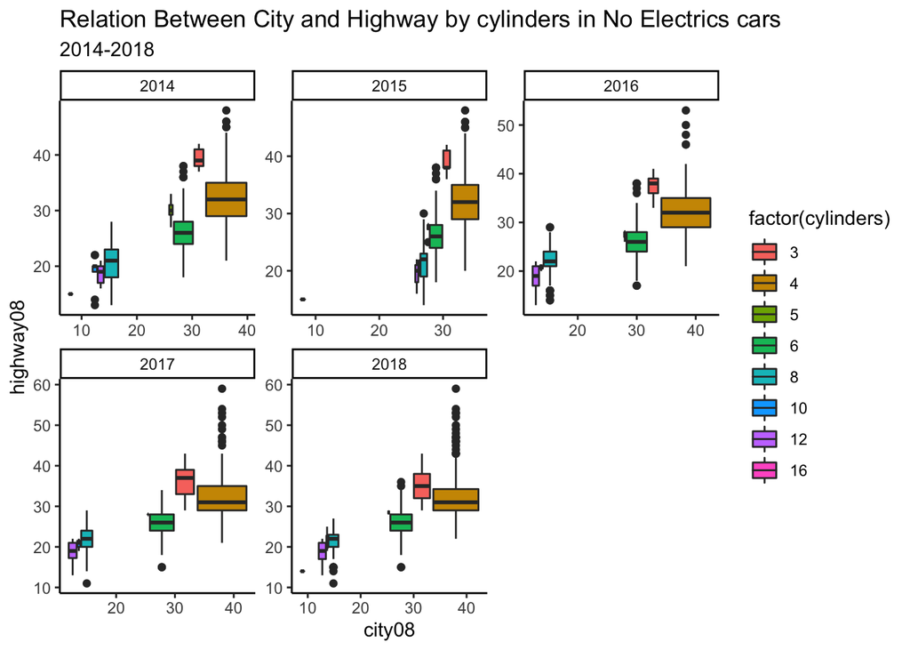

```
## # A tibble: 38 x 6
## # Groups:   year [5]
##     year cylinders avg_city avg_highway median_city median_highway
##    <dbl>     <dbl>    <dbl>       <dbl>       <dbl>          <dbl>
##  1  2018         3     27.3        35.5          27           35
##  2  2018         4     24.6        32.1          23           31
##  3  2018         5     19          28.5          19           28.5
##  4  2018         6     18.6        25.7          18           26
##  5  2018         8     15.1        21.8          15           22
##  6  2018        10     13.9        21.6          14           21.5
##  7  2018        12     12.1        18.9          12           19
##  8  2018        16      9          14             9           14
##  9  2017         3     28.3        36.6          28           37
## 10  2017         4     24.6        32.0          23           31
## # … with 28 more rows
```

La evidencia muestra que si hay variaciones a favor entre la relación de distancia y el número de cilindros.

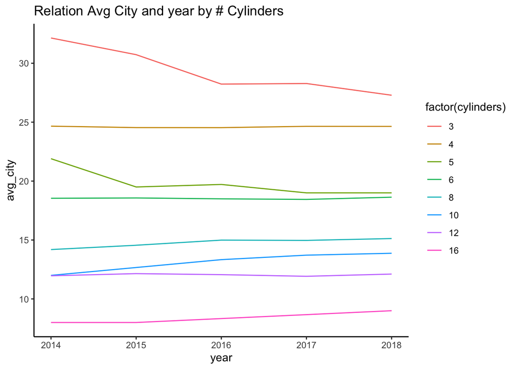

Anotación importante: ** Con los años, los carros con menor número de cilindros están bajando su rendimiento, mientras que los de más alto cilindraje aumentaron en una mínima proporción.

Visto de una manera historica , el comportamiento es el siguiente

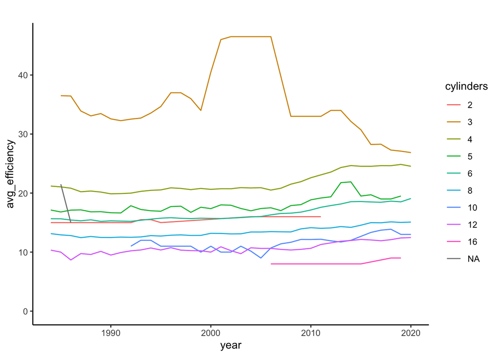

```r
big_epa_cars%>%
  filter(cityE==0)%>%
  group_by(year, cylinders)%>%
  summarize(avg_efficiency=mean(city08))%>%
  ggplot(aes(year,avg_efficiency, color=factor(cylinders)))+
  geom_line()+
  labs(col='cylinders', title = '')+
  expand_limits(y=0)
```

Si se evalua la misma relación pero en el caso de los carros electricos el resultado es el siguiente

```
##
## Correlation method: 'pearson'
## Missing treated using: 'pairwise.complete.obs'
```

| rowname | city08 | highway08 | displ | cylinders |
| --- | --- | --- | --- | --- |
| city08 | NA | 0.9249049 | -0.7314910 | -0.6947143 |
| highway08 | 0.9249049 | NA | -0.7112885 | -0.6482020 |
| displ | -0.7314910 | -0.7112885 | NA | 0.9044515 |
| cylinders | -0.6947143 | -0.6482020 | 0.9044515 | NA |

[output not shown]